# Post-hocs for MANOVA

with and without interactions

# Post-hocs

- Like ANOVA, MANOVA is done in two stages:
  - Omnibus test = tests of predictors, in the ANOVA/MANOVA table
  - Post-hocs = comparisons of group means/centroids done only after a significant omnibus test
- Example: effect of alcohol and opioid pain killers on heart rate and respiration rate

## An experiment:

- Three groups:
  - Control
  - Alcohol
  - Oxycodone
- Measure each patient’s heart rate and respiration rate

## False positives

- Post-hocs are designed to avoid the false positive inflation problem
  - Only after a significant A/MANOVA
  - Test at a more stringent level so that the **family-wise** rate stays at 0.05
- We have both univariate and multivariate post-hocs now

## Multivariate post-hocs

- Group differences may be multivariate
- **Pairwise** comparisons = comparison of all possible pairs of groups
  - Not the same as testing paired measurements = **paired** comparisons
- Pairwise Hotelling T<sup>2</sup>

## Univariate post-hocs

- Can just do Tukey post-hocs on a one-way ANOVA for each predictor
- But, comparisons on different variables from the same cases are not independent
  - Do a Tukey procedure for each response variable
  - Adjust for total number of p-values generated

## Univariate post-hocs

# Interactions

- What they are, questions they address
- Post-hocs

## When response to one factor depends on another

- Combining two treatments together can lead to:
  - Additive effects (each independent)
  - Synergistic effects (one amplifies effect of other)
  - Inhibitory effects (one dampens effect of other)
- Example: drug interactions

## The best design to test for interactions

- Cross the factors
  - Use all combinations of alcohol and opioid (A-O-, A+O-, A-O+, A+O+)
- Balance the design
  - Use same number of people in each combination

|  |  | Alcohol |  |
| --- | --- | --- | --- |
|  |  | Yes | No |
| **Opioids** | Yes | A+O+ | A-O+ |
|  | No | A+O- | A-O- |

## Analysis of the data

- Use a column for each predictor (alcohol, opioids)
- Fit lm(hr ~ alcohol * opioids)
  - The multiplication symbol, *, indicates an interaction
  - Main effects are automatically included
- The ANOVA table has a row for each main effect, and another for the alcohol x opioid interaction

# Interactions

- What they are, questions they address
- Post-hocs

## We don’t always want all pairs

- There can be many pairs of means when all possible combinations are used
- May not care about some of the comparisons
- Each comparison adjusted for reduces power
- Common alternatives:
  - Compare alcohol treatments within each opioid treatment
  - Compare opioid treatments within each alcohol treatment

# Generalizing to multivariate data

- We measured heart rate and respiration rate
- What do interactions look like for both at once?

## Interaction plot

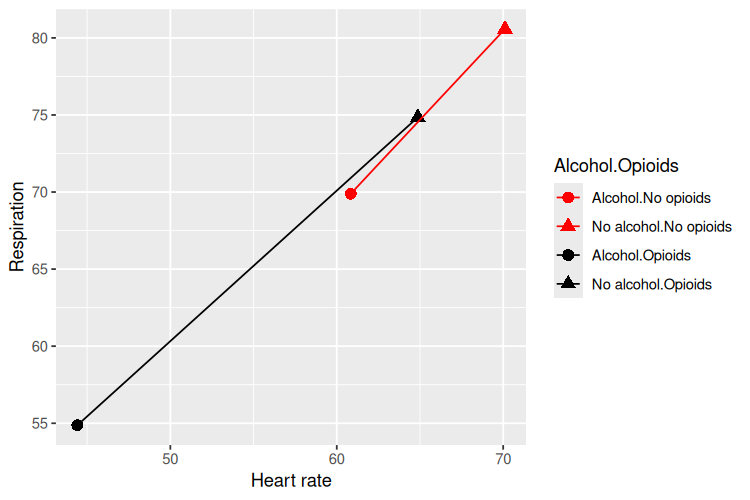

Lengths differ, so response to opioids depends on alcohol consumption

## Univariate post-hocs

# Adjusting α

- All of our post-hocs used adjusted p-values
- If this is not available for some reason can adjust α instead
- Bonferonni correction: α/k
  - k is the number of things you need to correct for
  - If we got Tukey tests for each response we could test at 0.05/2 = 0.025 to correct for the two non-independent set of tests

# Wrapup

- Post-hocs protect against false positives
  - Adjust for non-independent comparisons
- Multivariate analysis has two types:
  - Multivariate post-hocs, adjust α for number of comparisons
  - Univariate post-hocs, Tukey adjusts for number of comparisons, but adjust α for number of variables
- Interactions test for dependence of response on combinations of predictors
  - Post-hocs on combinations when interaction is significant
  - Focus on main effects when interaction is not significant